# Fashion-MNIST 실습

## CNN

- Step 1. Fashion-MNIST 데이터셋 가져오기
- Step 2. Keras로 CNN 구성하기
- Step 3. Train 데이터로 학습하기
- Step 4. Test 데이터로 성능평가

이 튜토리얼에서는 운동화나 셔츠 같은 옷 이미지를 분류하는 신경망 모델을 훈련해 보겠습니다.  
10개의 범주(category)와 70,000개의 흑백 이미지로 구성된 패션 MNIST 데이터셋을 사용할 겁니다!

**데이터셋 공식 홈페이지** : https://github.com/zalandoresearch/fashion-mnist

이미지는 해상도(28x28 픽셀)가 낮고 다음처럼 개별 옷 품목을 나타냅니다:

[figure not shown]

### 레이블들(labels)

모든 데이터는 다음의 값으로 레이블 되어 있습니다.

| Label | Description |
| --- | --- |
| 0 | T-shirt/top |
| 1 | Trouser |
| 2 | Pullover |
| 3 | Dress |
| 4 | Coat |
| 5 | Sandal |
| 6 | Shirt |
| 7 | Sneaker |
| 8 | Bag |
| 9 | Ankle boot |

Fashion-MNIST는 컴퓨터 비전 분야의 "Hello, World" 프로그램격인 고전 MNIST 데이터셋을 대신해서 자주 사용됩니다. MNIST 데이터셋은 손글씨 숫자(0, 1, 2 등)의 이미지로 이루어져 있습니다. 여기서 사용하려는 옷 이미지와 동일한 포맷입니다.

Fashion-MNIST는 일반적인 MNIST 보다 조금 더 어려운 문제이고 다양한 예제를 만들기 위해 사용됩니다. 두 데이터셋은 비교적 작기 때문에 알고리즘의 작동 여부를 확인하기 위해 사용되곤 합니다. 코드를 테스트하고 디버깅하는 용도로 좋습니다.

네트워크를 훈련하는데 60,000개의 이미지를 사용합니다. 그다음 네트워크가 얼마나 정확하게 이미지를 분류하는지 10,000개의 이미지로 평가하겠습니다.

일단 시작하기 전에 다른 모델들은 얼마나 성과를 내었는지 궁금할 수 있습니다.

먼저 `scikit-learn`으로 여러 기계학습 모델들을 사용했을 때의 정확도에 대한 대시보드입니다.

**대시보드** : http://fashion-mnist.s3-website.eu-central-1.amazonaws.com/

[figure not shown]

그리고 딥러닝 모델들을 사용한 [정확도 결과](https://github.com/zalandoresearch/fashion-mnist/edit/master/README.md)입니다. 각 행의 가장 오른쪽 끝에 코드도 같이 공개되어 있으니 참고하시면 좋을 것 같습니다!

| Classifier | Preprocessing | Fashion test accuracy | MNIST test accuracy | Submitter | Code |
| --- | --- | --- | --- | --- | --- |
| 2 Conv+pooling | None | 0.876 | - | [Kashif Rasul](https://twitter.com/krasul) | [:link:](https://gist.github.com/kashif/76792939dd6f473b7404474989cb62a8) |
| 2 Conv+pooling | None | 0.916 | - | [Tensorflow's doc](https://www.tensorflow.org/tutorials/layers) | [:link:](https://github.com/zalandoresearch/fashion-mnist/blob/master/benchmark/convnet.py) |
| 2 Conv+pooling+ELU activation (PyTorch) | None | 0.903 | - | [@AbhirajHinge](https://github.com/AbhirajHinge) | [:link:](https://github.com/AbhirajHinge/CNN-with-Fashion-MNIST-dataset) |
| 2 Conv | Normalization, random horizontal flip, random vertical flip, random translation, random rotation. | 0.919 | 0.971 | [Kyriakos Efthymiadis](https://github.com/kefth) | [:link:](https://github.com/kefth/fashion-mnist) |
| 2 Conv <100K parameters | None | 0.925 | 0.992 | [@hardmaru](https://twitter.com/hardmaru) | [:link:](https://github.com/hardmaru/pytorch_notebooks/blob/master/pytorch_tiny_custom_mnist_adam.ipynb) |
| 2 Conv ~113K parameters | Normalization | 0.922 | 0.993 | [Abel G.](https://github.com/abelusha) | [:link:](https://github.com/abelusha/MNIST-Fashion-CNN/blob/master/Fashon_MNIST_CNN_using_Keras_10_Runs.ipynb) |
| 2 Conv+3 FC ~1.8M parameters | Normalization | 0.932 | 0.994 | [@Xfan1025](https://github.com/Xfan1025) | [:link:](https://github.com/Xfan1025/Fashion-MNIST/blob/master/fashion-mnist.ipynb) |
| 2 Conv+3 FC ~500K parameters | Augmentation, batch normalization | 0.934 | 0.994 | [@cmasch](https://github.com/cmasch) | [:link:](https://github.com/cmasch/zalando-fashion-mnist) |
| 2 Conv+pooling+BN | None | 0.934 | - | [@khanguyen1207](https://github.com/khanguyen1207) | [:link:](https://github.com/khanguyen1207/My-Machine-Learning-Corner/blob/master/Zalando%20MNIST/fashion.ipynb) |
| 2 Conv+2 FC | Random Horizontal Flips | 0.939 | - | [@ashmeet13](https://github.com/ashmeet13) | [:link:](https://github.com/ashmeet13/FashionMNIST-CNN) |
| 3 Conv+2 FC | None | 0.907 | - | [@Cenk Bircanoğlu](https://github.com/cenkbircanoglu) | [:link:](https://github.com/cenkbircanoglu/openface/tree/master/fashion_mnist) |
| 3 Conv+pooling+BN | None | 0.903 | 0.994 | [@meghanabhange](https://github.com/meghanabhange) | [:link:](https://github.com/meghanabhange/FashionMNIST-3-Layer-CNN) |
| 3 Conv+pooling+2 FC+dropout | None | 0.926 | - | [@Umberto Griffo](https://github.com/umbertogriffo) | [:link:](https://github.com/umbertogriffo/Fashion-mnist-cnn-keras) |
| 3 Conv+BN+pooling | None | 0.921 | 0.992 | [@gchhablani](https://github.com/gchhablani) | [:link:](https://github.com/gchhablani/CNN-with-FashionMNIST) |
| 5 Conv+BN+pooling | None | 0.931 | - | [@Noumanmufc1](https://github.com/Noumanmufc1) | [:link:](https://gist.github.com/Noumanmufc1/60f00e434f0ce42b6f4826029737490a) |
| CNN with optional shortcuts, dense-like connectivity | standardization+augmentation+random erasing | 0.947 | - | [@kennivich](https://github.com/Dezhic) | [:link:](https://github.com/Dezhic/fashion-classifier) |
| GRU+SVM | None | 0.888 | 0.965 | [@AFAgarap](https://github.com/AFAgarap) | [:link:](https://gist.githubusercontent.com/AFAgarap/92c1c4a5dd771999b0201ec0e7edfee0/raw/828fbda0e466dacb1fad66549e0e3022e1c7263a/gru_svm_zalando.py) |
| GRU+SVM with dropout | None | 0.897 | 0.988 | [@AFAgarap](https://github.com/AFAgarap) | [:link:](https://gist.githubusercontent.com/AFAgarap/92c1c4a5dd771999b0201ec0e7edfee0/raw/58dbe7cd8b0d83e4386cd6896766113b1a9af096/gru_svm_zalando_dropout.py) |
| WRN40-4 8.9M params | standard preprocessing (mean/std subtraction/division) and augmentation (random crops/horizontal flips) | 0.967 | - | [@ajbrock](https://github.com/ajbrock) | [:link:](https://github.com/xternalz/WideResNet-pytorch) [:link:](https://github.com/ajbrock/FreezeOut) |
| DenseNet-BC 768K params | standard preprocessing (mean/std subtraction/division) and augmentation (random crops/horizontal flips) | 0.954 | - | [@ajbrock](https://github.com/ajbrock) | [:link:](https://github.com/bamos/densenet.pytorch) [:link:](https://github.com/ajbrock/FreezeOut) |
| MobileNet | augmentation (horizontal flips) | 0.950 | - | [@苏剑林](https://github.com/bojone) | [:link:](http://kexue.fm/archives/4556/) |
| ResNet18 | Normalization, random horizontal flip, random vertical flip, random translation, random rotation. | 0.949 | 0.979 | [Kyriakos Efthymiadis](https://github.com/kefth) | [:link:](https://github.com/kefth/fashion-mnist) |
| GoogleNet with cross-entropy loss | None | 0.937 | - | [@Cenk Bircanoğlu](https://github.com/cenkbircanoglu) | [:link:](https://github.com/cenkbircanoglu/openface/tree/master/fashion_mnist) |
| AlexNet with Triplet loss | None | 0.899 | - | [@Cenk Bircanoğlu](https://github.com/cenkbircanoglu) | [:link:](https://github.com/cenkbircanoglu/openface/tree/master/fashion_mnist) |
| SqueezeNet with cyclical learning rate 200 epochs | None | 0.900 | - | [@snakers4](https://github.com/snakers4) | [:link:](https://github.com/zalandoresearch/fashion-mnist/files/1263340/squeeze_net_mnist.zip) |
| Dual path network with wide resnet 28-10 | standard preprocessing (mean/std subtraction/division) and augmentation (random crops/horizontal flips) | 0.957 | - | [@Queequeg](https://github.com/Queequeg92) | [:link:](https://github.com/Queequeg92/DualPathNet) |
| MLP 256-128-100 | None | 0.8833 | - | [@heitorrapela](https://github.com/heitorrapela) | [:link:](https://github.com/heitorrapela/fashion-mnist-mlp) |
| VGG16 26M parameters | None | 0.935 | - | [@QuantumLiu](https://github.com/QuantumLiu) | [:link:](https://github.com/QuantumLiu/fashion-mnist-demo-by-Keras) [:link:](https://zhuanlan.zhihu.com/p/28968219) |
| WRN-28-10 | standard preprocessing (mean/std subtraction/division) and augmentation (random crops/horizontal flips) | 0.959 | - | [@zhunzhong07](https://github.com/zhunzhong07) | [:link:](https://github.com/zhunzhong07/Random-Erasing) |
| WRN-28-10 + Random Erasing | standard preprocessing (mean/std subtraction/division) and augmentation (random crops/horizontal flips) | 0.963 | - | [@zhunzhong07](https://github.com/zhunzhong07) | [:link:](https://github.com/zhunzhong07/Random-Erasing) |
| Human Performance | Crowd-sourced evaluation of human (with no fashion expertise) performance. 1000 randomly sampled test images, 3 labels per image, majority labelling. | 0.835 | - | Leo | - |
| Capsule Network 8M parameters | Normalization and shift at most 2 pixel and horizontal flip | 0.936 | - | [@XifengGuo](https://github.com/XifengGuo) | [:link:](https://github.com/XifengGuo/CapsNet-Fashion-MNIST) |
| HOG+SVM | HOG | 0.926 | - | [@subalde](https://github.com/subalde) | [:link:](https://github.com/subalde/fashion-mnist) |
| XgBoost | scaling the pixel values to mean=0.0 and var=1.0 | 0.898 | 0.958 | [@anktplwl91](https://github.com/anktplwl91) | [:link:](https://github.com/anktplwl91/fashion_mnist.git) |
| DENSER | - | 0.953 | 0.997 | [@fillassuncao](https://github.com/fillassuncao) | [:link:](https://github.com/fillassuncao/denser-models) [:link:](https://arxiv.org/pdf/1801.01563.pdf) |
| Dyra-Net | Rescale to unit interval | 0.906 | - | [@Dirk Schäfer](https://github.com/disc5) | [:link:](https://github.com/disc5/dyra-net) [:link:](https://dl.acm.org/citation.cfm?id=3204176.3204200) |
| Google AutoML | 24 compute hours (higher quality) | 0.939 | - | [@Sebastian Heinz](https://github.com/sebastianheinz) | [:link:](https://www.statworx.com/de/blog/a-performance-benchmark-of-google-automl-vision-using-fashion-mnist/) |
| Fastai | Resnet50+Fine-tuning+Softmax on last layer's activations | 0.9312 | - | [@Sayak](https://github.com/sayakpaul) | [:link:](https://github.com/sayakpaul/Experiments-on-Fashion-MNIST/) |

Fashion-MNIST 데이터셋은 공식 홈페이지에서 다운 받으셔도 되지만, Keras에서 바로 임포트하여 사용할 수 있습니다! ^^  
저희는 Keras를 이용해서 진행해 보겠습니다.

## 파이썬 라이브러리 불러오기

사용할 라이브러리들을 불러옵니다.

## 데이터셋 불러오기

Keras의 datasets를 이용해 FashionMNIST 데이터셋을 불러오겠습니다.

```
X_train shape (60000, 28, 28)
y_train shape (60000,)
X_test shape (10000, 28, 28)
y_test shape (10000,)
```

불러온 데이터를 그림으로 한 번 그려보겠습니다.  
데이터가 많으니 무작위로 몇 개를 골라서 그려보겠습니다.  
셀을 다시 실행하면 또 다른 무작위 그림이 출력됩니다.

그림을 그리기 전에 한글 레이블을 표시하려면 폰트 위치를 지정해 주어야 합니다.  
지금 시스템이 갖고 있는 폰트 목록을 출력하겠습니다.

이 중에 한글 폰트를 찾아서 아래 `fname`의 값으로 넣어줍니다.

이제 그림을 출력해 보죠.

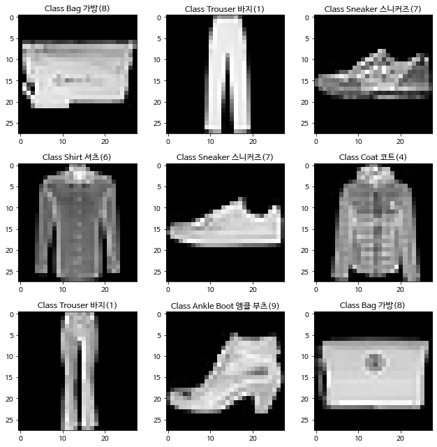

이미지 말고 배열로도 그려보겠습니다

```
0  0  0  0  0  0  0  0  0  0    0   97   84   97  110  108   87   97    0  0  0  0  0  0  0  0  0  0
0  0  0  0  0  0  0  0  0  0   19  255  199  183  142  161  200  213   32  0  0  0  0  0  0  0  0  0
0  0  0  0  0  0  0  0  0  0   72  174  173  158  131  132  176  176   70  0  0  0  0  0  0  0  0  0
0  0  0  0  0  0  0  0  0  0  142  180  163  120  180  126  139  168  122  0  0  0  0  0  0  0  0  0
0  0  0  0  0  0  0  0  0  0  156  180  162  171  170  183  163  169  144  0  0  0  0  0  0  0  0  0
0  0  0  0  0  0  0  0  0  0  159  177  163  174  166  173  170  163  148  0  0  0  0  0  0  0  0  0
0  0  0  0  0  0  0  0  0  0  160  182  160  168  175  167  157  168  139  0  0  0  0  0  0  0  0  0
0  0  0  0  0  0  0  0  0  0  143  185  161  171  184  176  160  175  131  0  0  0  0  0  0  0  0  0
0  0  0  0  0  0  0  0  0  0  143  188  155  172  182  180  161  182  127  0  0  0  0  0  0  0  0  0
0  0  0  0  0  0  0  0  0  0  127  170  168  175  211  191  163  184  113  0  0  0  0  0  0  0  0  0
0  0  0  0  0  0  0  0  0  0   78  132  175  177  129  203  161  187  102  0  0  0  0  0  0  0  0  0
0  0  0  0  0  0  0  0  0  0   91  166  163  190   63  203  159  189   94  0  0  0  0  0  0  0  0  0
0  0  0  0  0  0  0  0  0  0   98  126  166  192   65  198  167  193   84  0  0  0  0  0  0  0  0  0
0  0  0  0  0  0  0  0  0  0   90  127  170  198   61  200  174  198   71  0  0  0  0  0  0  0  0  0
0  0  0  0  0  0  0  0  0  0   93  141  151  207   55  196  171  196   58  0  0  0  0  0  0  0  0  0
0  0  0  0  0  0  0  0  0  0   88  137  136  210   54  198  173  199   46  0  0  0  0  0  0  0  0  0
0  0  0  0  0  0  0  0  0  0   72  125  131  214   55  199  176  200   38  0  0  0  0  0  0  0  0  0
0  0  0  0  0  0  0  0  0  0   56  146  126  210   56  200  175  200   37  0  0  0  0  0  0  0  0  0
0  0  0  0  0  0  0  0  0  0   40  237  171  195   64  199  174  203   36  0  0  0  0  0  0  0  0  0
0  0  0  0  0  0  0  0  0  0   23  190  168  192   70  196  171  203   30  0  0  0  0  0  0  0  0  0
0  0  0  0  0  0  0  0  0  0   15  188  171  196   70  198  173  202   21  0  0  0  0  0  0  0  0  0
0  0  0  0  0  0  0  0  0  0   11  187  172  197   71  199  174  203   15  0  0  0  0  0  0  0  0  0
0  0  0  0  0  0  0  0  0  0    1  183  175  198   73  195  174  205   13  0  0  0  0  0  0  0  0  0
0  0  0  0  0  0  0  0  0  0    0  186  177  200   78  191  175  171    8  0  0  0  0  0  0  0  0  0
0  0  0  0  0  0  0  0  0  0    0  181  177  198   78  189  176  166    4  0  0  0  0  0  0  0  0  0
0  0  0  0  0  0  0  0  0  0    0  178  182  182  107  184  175  193    0  0  0  0  0  0  0  0  0  0
0  0  0  0  0  0  0  0  0  0    0  173  200  206   84  196  196  133    0  0  0  0  0  0  0  0  0  0
0  0  0  0  0  0  0  0  0  0    0   68  207  182    0  175  195   34    0  0  0  0  0  0  0  0  0  0
==========
정답 : Trouser 바지 1
```

각 픽셀은 8bit 정수이며, 0부터 255 사이의 값을 갖습니다.  
이미지에서 숫자 `0`은 검정, 숫자 `255`는 하양을 표현합니다.

이것을 싱글-채널 픽셀이라고 부르며, 단색(monochrome)이라고 합니다.

# 합성곱 (콘볼루션, Convolution)

CNN에서는 이미지의 특징들(곡률, 가장자리 등)을 신경망에 입력하고 신경망이 이미지 분류에 중요한 특징을 학습할 수 있도록 합니다.  
특징 입력을 위해서 합성곱(Convolution)을 사용할 겁니다.  
합성곱은 커널(kernel or filter)를 적용해서 특징맵(feature map)을 생성합니다.

[figure not shown]

위의 예에서 이미지는 5x5 행렬이고 여기에 합성곱을 할 커널은 3x3 행렬입니다.  
내적(dot product) 연산이 이미지와 커널 사이에서 발생하고 합성곱 된 특징맵이 만들어 집니다.  
CNN의 각 커널은 이미지의 다른 특성을 학습합니다.

커널은 사진 편집 소프트웨어에서 흐림(blur), 가장자리 감지(edge detection), 선명화(sharpening) 등을 적용하는 데 자주 사용됩니다.  
아래 표에서 필터의 값을 한 번 확인해 보세요.

https://en.wikipedia.org/wiki/Kernel_(image_processing)

[figure not shown]

CNN에서 사용하는 커널은 위에서 사용한 커널들을 사용할 수도 있지만, 보통 최대 풀링(Max pooling)을 사용합니다.

**최대 풀링**은 가장 큰 값을 남기는 방식을 말합니다. 이는 작은 값 요소가 각 특징 맵에서 삭제되어 중요할 수 있는 부분만을 남기고 학습할 매개 변수 수를 줄이며 계산 비용(예 : 시스템 메모리)을 줄이는 효과가 있습니다.

- 앞으로 나아가는 매개 변수의 양을 줄여 계산 부하를 줄이기 위해서
- 값이 높은 픽셀이 가장 많이 활성화되어 잡아내기(capture) 위해서

[figure not shown]

컨볼루션의 컨볼루션을 취할 수도 있으며, Keras를 이용해 컨볼루션 층을 깊게 한 번 쌓아보도록 하죠!

[figure not shown]

## 깊은 CNN 만들기

```
X_train shape (60000, 28, 28)
y_train shape (60000,)
X_test shape (10000, 28, 28)
y_test shape (10000,)
학습 행렬 모양 : (60000, 28, 28, 1)
테스트 행렬 모양 (10000, 28, 28, 1)
```

Sequential()로 모델을 쌓아보겠습니다.

```
Model: "sequential"
_________________________________________________________________
Layer (type)                 Output Shape              Param #
=================================================================
conv2d (Conv2D)              (None, 26, 26, 32)        320
_________________________________________________________________
batch_normalization (BatchNo (None, 26, 26, 32)        128
_________________________________________________________________
activation (Activation)      (None, 26, 26, 32)        0
_________________________________________________________________
conv2d_1 (Conv2D)            (None, 24, 24, 32)        9248
_________________________________________________________________
batch_normalization_1 (Batch (None, 24, 24, 32)        128
_________________________________________________________________
activation_1 (Activation)    (None, 24, 24, 32)        0
_________________________________________________________________
max_pooling2d (MaxPooling2D) (None, 12, 12, 32)        0
_________________________________________________________________
conv2d_2 (Conv2D)            (None, 10, 10, 64)        18496
_________________________________________________________________
batch_normalization_2 (Batch (None, 10, 10, 64)        256
_________________________________________________________________
activation_2 (Activation)    (None, 10, 10, 64)        0
_________________________________________________________________
conv2d_3 (Conv2D)            (None, 8, 8, 64)          36928
_________________________________________________________________
batch_normalization_3 (Batch (None, 8, 8, 64)          256
_________________________________________________________________
activation_3 (Activation)    (None, 8, 8, 64)          0
_________________________________________________________________
max_pooling2d_1 (MaxPooling2 (None, 4, 4, 64)          0
_________________________________________________________________
flatten (Flatten)            (None, 1024)              0
_________________________________________________________________
dense (Dense)                (None, 512)               524800
_________________________________________________________________
batch_normalization_4 (Batch (None, 512)               2048
_________________________________________________________________
activation_4 (Activation)    (None, 512)               0
_________________________________________________________________
dropout (Dropout)            (None, 512)               0
_________________________________________________________________
dense_1 (Dense)              (None, 10)                5130
_________________________________________________________________
activation_5 (Activation)    (None, 10)                0
=================================================================
Total params: 597,738
Trainable params: 596,330
Non-trainable params: 1,408
_________________________________________________________________
```

하나의 테크닉으로 **데이터 증강(Data Augmentation)**을 수행하겠습니다.  
데이터 증강은 데이터를 무작위로 약간 변경하여 과적합(overfitting)을 방지합니다.  
Keras에는 자동 증강을 수행하는 훌륭한 내장(built-in) 기능이 있습니다.

만약 이미지의 양이 많다면, 제너레이터 형식으로 데이터를 입력시킬 수 있습니다.  
메모리에 모두 올려서 쓰는 것이 아니라 사용할 때 로드하여 사용하는 방식입니다. (이를 feeding 한다고 합니다)  
이 방법은 상당한 메모리 절약을 가져옵니다.

참고자료 : https://stanford.edu/~shervine/blog/keras-how-to-generate-data-on-the-fly

이 때 `steps_per_epoch`의 값은 샘플의 개수를 배치 사이즈로 나누어야 함을 잊지 마세요! $$\biggl\lfloor\frac{\#\textrm{ samples}}{\textrm{batch size}}\biggr\rfloor$$

```
Test score: 0.2819076180458069
Test accuracy: 0.894599974155426
```

### 결과 살펴보기

- 정답인 경우

[figure not shown]

- 오답인 경우 (왼쪽 예측, 오른쪽 정답)

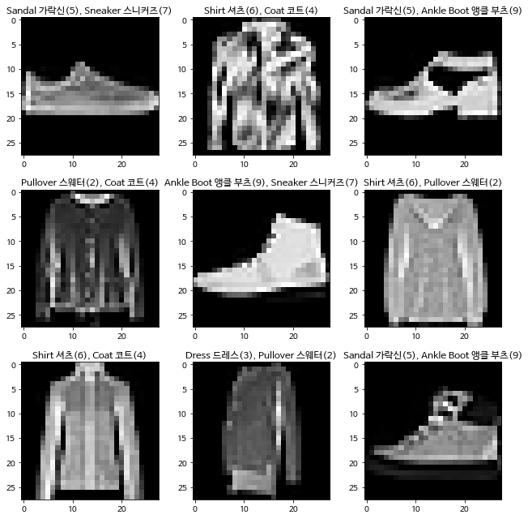

# 학습 시각화

딥러닝 모델은 Black Box 라고도 얘기하는데요, 잘 작동하는 모델이라도 왜 잘 작동하는지 그 내부를 사람이 이해하기 어렵기 때문입니다.

하지만 CNN은 할 수 있습니다! 시각적인 개념(이미지)을 학습한 것이기 때문에 그 내부도 시각화하기 매우 좋습니다.

## 중간층의 activation 시각화하기

중간층의 activation 시각화는 어떤 입력이 주어졌을 때 네트워크에 있는 여러 합성곱과 풀링 층이 출력하는 특성 맵을 그리는 것입니다.  
(layer의 출력이 활성화 함수의 출력이라서 **activation**이라고 부릅니다)

이 방법은 신경망에 의해 학습된 필터들이 **어떻게 입력을 분해하는지** 보여줍니다.

넓이, 높이, 깊이(채널) 3개의 차원에 대해 특성 맵을 시각화하는 것이 좋습니다.  
각 채널은 비교적 독립적인 특성을 인코딩하므로 특성 맵의 각 채널 내용을 독립적인 2D 이미지로 그리는 것이 괜찮은 방법입니다.

한 번 그려보겠습니다.

시각화를 하기 위해서 입력할 이미지 하나를 선택해 볼께요.

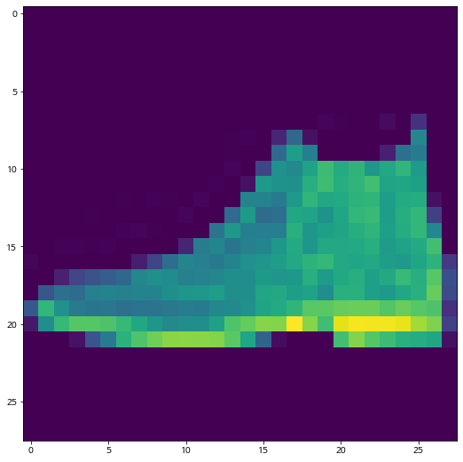

우리 모델의 구조는 다음과 같았습니다.

```
Model: "sequential"
_________________________________________________________________
Layer (type)                 Output Shape              Param #
=================================================================
conv2d (Conv2D)              (None, 26, 26, 32)        320
_________________________________________________________________
batch_normalization (BatchNo (None, 26, 26, 32)        128
_________________________________________________________________
activation (Activation)      (None, 26, 26, 32)        0
_________________________________________________________________
conv2d_1 (Conv2D)            (None, 24, 24, 32)        9248
_________________________________________________________________
batch_normalization_1 (Batch (None, 24, 24, 32)        128
_________________________________________________________________
activation_1 (Activation)    (None, 24, 24, 32)        0
_________________________________________________________________
max_pooling2d (MaxPooling2D) (None, 12, 12, 32)        0
_________________________________________________________________
conv2d_2 (Conv2D)            (None, 10, 10, 64)        18496
_________________________________________________________________
batch_normalization_2 (Batch (None, 10, 10, 64)        256
_________________________________________________________________
activation_2 (Activation)    (None, 10, 10, 64)        0
_________________________________________________________________
conv2d_3 (Conv2D)            (None, 8, 8, 64)          36928
_________________________________________________________________
batch_normalization_3 (Batch (None, 8, 8, 64)          256
_________________________________________________________________
activation_3 (Activation)    (None, 8, 8, 64)          0
_________________________________________________________________
max_pooling2d_1 (MaxPooling2 (None, 4, 4, 64)          0
_________________________________________________________________
flatten (Flatten)            (None, 1024)              0
_________________________________________________________________
dense (Dense)                (None, 512)               524800
_________________________________________________________________
batch_normalization_4 (Batch (None, 512)               2048
_________________________________________________________________
activation_4 (Activation)    (None, 512)               0
_________________________________________________________________
dropout (Dropout)            (None, 512)               0
_________________________________________________________________
dense_1 (Dense)              (None, 10)                5130
_________________________________________________________________
activation_5 (Activation)    (None, 10)                0
=================================================================
Total params: 597,738
Trainable params: 596,330
Non-trainable params: 1,408
_________________________________________________________________
```

이 모델에서 첫 번째 레이어는 다음과 같이 선택할 수 있습니다.

```
<keras.layers.convolutional.Conv2D at 0x7fd11b137550>
```

그리고 여러 개를 선택할 수도 있죠.

```
[<keras.layers.convolutional.Conv2D at 0x7fd11b137550>,
 <keras.layers.normalization.BatchNormalization at 0x7fd11b1375b0>,
 <keras.layers.core.Activation at 0x7fd126560ca0>]
```

출력이 어떻게 생겼는지(dimension)는 `.output`을 통해 확인할 수 있습니다.

```
<KerasTensor: shape=(None, 26, 26, 32) dtype=float32 (created by layer 'conv2d')>
```

```
<KerasTensor: shape=(None, 26, 26, 32) dtype=float32 (created by layer 'activation')>
```

이 출력층만을 모델로 만들기 위해 모듈을 하나 import 합니다.  
모델 인스턴스를 만들 때는 두 개의 매개변수가 필요합니다. 입력텐서(inputs)와 출력텐서(outputs)입니다.

layer의 activation마다 하나씩 `14`개의 `numpy array`로 이루어진 리스트를 반환합니다.

```
14
```

첫 번째 conv layer의 activation 값을 한 번 그려보죠

```
(1, 26, 26, 32)
```

32개의 채널을 가진 26x26 크기의 특성 맵 입니다.

원본 모델의 첫 번째 layer activation 중에서 `5`번째 채널을 그려 보겠습니다.

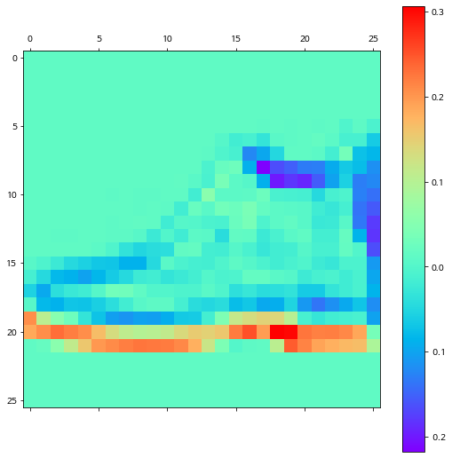

`5`번째 채널은 수평선 엣지를 감지하도록 인코딩된 것 같습니다.

`16`번째 채널을 볼까요?

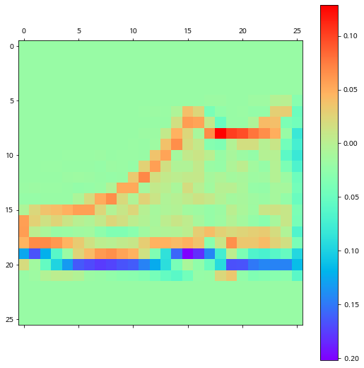

`16`번째 채널은 윤곽선 엣지를 감지하도록 인코딩된 것 같네요!

하나씩 살펴보면 귀찮으니 신경망의 모든 activation을 시각화해 보겠습니다.  
14개의 activation 맵에서 추출한 모든 채널을 그리기 위해 하나의 큰 이미지 텐서에 추출한 결과를 나란히 append 하겠습니다.

```
['conv2d',
 'batch_normalization',
 'activation',
 'conv2d_1',
 'batch_normalization_1',
 'activation_1',
 'max_pooling2d',
 'conv2d_2',
 'batch_normalization_2',
 'activation_2',
 'conv2d_3',
 'batch_normalization_3',
 'activation_3',
 'max_pooling2d_1']
```

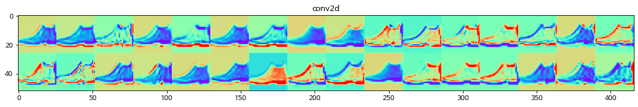

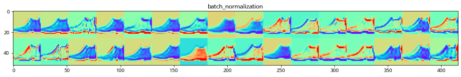

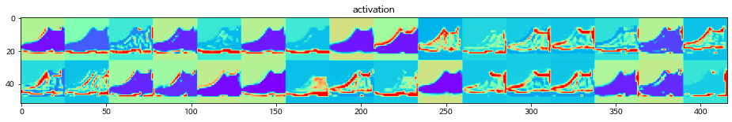

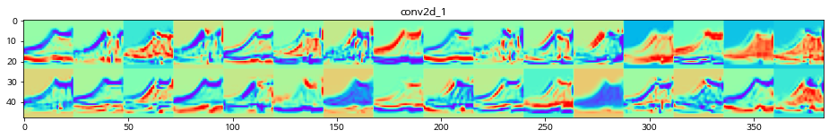

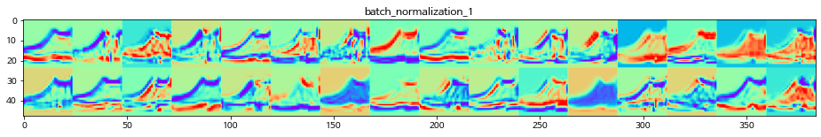

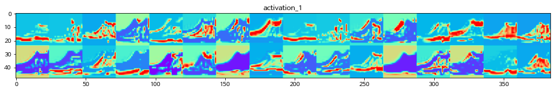

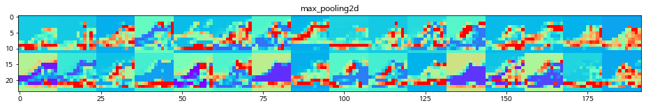

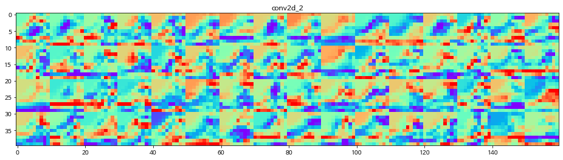

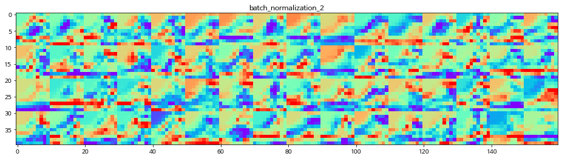

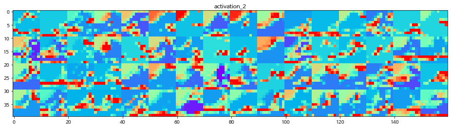

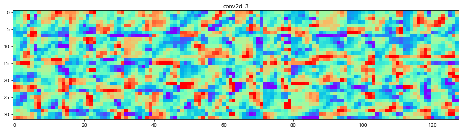

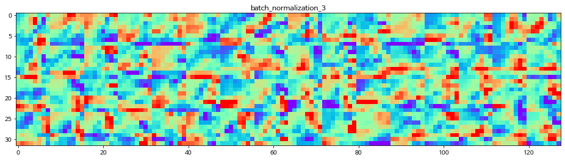

[2 more figures not shown]

# activation 시각화 도전!

각 시각화 층에서 주목되는 특징이 있지요?!  
이를 정리해 보면 다음과 같습니다.

- 첫 번째 layer는 여러 종류의 edge detector를 모아 놓은 것 같습니다.  
  이 단계의 activation에는 초기 사진에 있는 거의 모든 정보가 유지됩니다.
- 다음 layer로 갈수록 activation은 점점 더 추상적(abstract)으로 되고 시각적으로 이해하기 어려워집니다.  
  꺽인 부분, 둥근 부분 등 고수준(high-level) 개념을 인코딩하기 시작합니다.  
  상위 layer의 표현은 이미지의 시각적 콘텐츠에 대한 정보가 점점 줄어들고 타깃에 관한 정보가 점점 더 증가합니다.  
  깊은 신경망은 입력되는 원본 데이터에 대한 정보 정제 파이프라인처럼 작동합니다.  
  반복되는 변환을 통해 관계없는 정보를 걸러 내고 유용한 정보는 강조되면서 개선됩니다.

### 참고 자료

- https://www.tensorflow.org/tutorials/keras/classification?hl=ko
- https://www.kaggle.com/gpreda/cnn-with-tensorflow-keras-for-fashion-mnist/notebook
- https://github.com/zalandoresearch/fashion-mnist
- https://hanxiao.io/2018/09/28/Fashion-MNIST-Year-In-Review/